# SwiftKey Corpus: Sampling, Tokenization and Cleaning

Sonja Sahebzad

2026-09-19

# Purpose

This reproducible case study uses the official English SwiftKey corpus supplied by Coursera. It demonstrates how to inspect large text files without loading the complete corpus into memory, draw a small sample, tokenize text, and remove terms that should not be predicted. The resulting sample is intended for learning and initial exploration; a production language model requires broader validation.

# Locate the official files

```r
data_dir <- file.path("data", "final", "en_US")

corpus_files <- c(
  blogs = file.path(data_dir, "en_US.blogs.txt"),
  news = file.path(data_dir, "en_US.news.txt"),
  twitter = file.path(data_dir, "en_US.twitter.txt")
)

file_check <- data.frame(
  source = names(corpus_files),
  file = basename(corpus_files),
  exists = file.exists(corpus_files),
  size_mb = round(file.info(corpus_files)$size / 1024^2, 1),
  row.names = NULL
)

file_check
```

```
##    source              file exists size_mb
## 1   blogs   en_US.blogs.txt   TRUE   200.4
## 2    news    en_US.news.txt   TRUE   196.3
## 3 twitter en_US.twitter.txt   TRUE   159.4
```

```r
stopifnot(all(file_check$exists))
```

# Read a small sample in chunks

The function below processes one chunk at a time. A Bernoulli draw decides whether each line is retained. This follows the course advice to work with a manageable subset instead of loading hundreds of megabytes at once.

```r
sample_lines_chunked <- function(path,
                                 probability = 0.0005,
                                 chunk_size = 10000L,
                                 maximum = 2500L,
                                 seed = 20260919L) {
  set.seed(seed)
  # The archived corpus contains legacy Windows-1252 byte sequences.
  # Temporarily using that Windows locale prevents readLines() from stopping
  # when it encounters a byte that is not valid UTF-8.
  previous_ctype <- Sys.getlocale("LC_CTYPE")
  suppressWarnings(Sys.setlocale("LC_CTYPE", "English_United States.1252"))
  on.exit(Sys.setlocale("LC_CTYPE", previous_ctype), add = TRUE)

  connection <- file(path, open = "r")
  on.exit(close(connection), add = TRUE)

  selected <- character()
  lines_scanned <- 0L

  repeat {
    chunk <- readLines(
      connection,
      n = chunk_size,
      warn = FALSE,
      skipNul = TRUE
    )

    if (length(chunk) == 0L || length(selected) >= maximum) break

    lines_scanned <- lines_scanned + length(chunk)
    keep <- as.logical(rbinom(length(chunk), size = 1L, prob = probability))
    selected <- c(selected, chunk[keep])

    if (length(selected) > maximum) selected <- selected[seq_len(maximum)]
  }

  selected <- iconv(selected, from = "windows-1252", to = "UTF-8", sub = "byte")
  list(lines = selected, lines_scanned = lines_scanned)
}
```

```r
sampled <- lapply(
  seq_along(corpus_files),
  function(i) sample_lines_chunked(corpus_files[[i]], seed = 20260919L + i)
)
names(sampled) <- names(corpus_files)

sample_summary <- data.frame(
  source = names(sampled),
  lines_scanned = vapply(sampled, function(x) x$lines_scanned, integer(1)),
  lines_sampled = vapply(sampled, function(x) length(x$lines), integer(1)),
  row.names = NULL
)

sample_summary
```

```
##    source lines_scanned lines_sampled
## 1   blogs        899288           449
## 2    news       1010206           531
## 3 twitter       2360148          1134
```

```r
sample_text <- unlist(lapply(sampled, `[[`, "lines"), use.names = FALSE)
length(sample_text)
```

```
## [1] 2114
```

# Inspect the raw sample safely

Real web text can contain foreign-language fragments, malformed characters, URLs, user names and offensive language. For that reason, the report shows structural statistics rather than printing arbitrary raw lines.

```r
raw_quality <- data.frame(
  sampled_lines = length(sample_text),
  empty_lines = sum(!nzchar(trimws(sample_text))),
  lines_with_url = sum(grepl("https?://|www\\.", sample_text, ignore.case = TRUE)),
  lines_with_at_mention = sum(grepl("@[[:alnum:]_]", sample_text)),
  median_characters = median(nchar(sample_text, type = "chars")),
  maximum_characters = max(nchar(sample_text, type = "chars"))
)

raw_quality
```

```
##   sampled_lines empty_lines lines_with_url lines_with_at_mention
## 1          2114           0              8                     3
##   median_characters maximum_characters
## 1                93               2297
```

# Tokenization

The tokenizer converts text to lowercase, removes URLs and user mentions, keeps apostrophes inside words, replaces other characters with spaces, and returns individual word tokens. Numbers and punctuation are excluded because this first model focuses on word prediction.

```r
tokenize_words <- function(lines) {
  lines <- enc2utf8(lines)
  lines <- tolower(lines)
  lines <- gsub("https?://[^[:space:]]+|www\\.[^[:space:]]+", " ", lines)
  lines <- gsub("@[[:alnum:]_]+", " ", lines)
  # The target corpus is English. Restricting tokens to ASCII letters removes
  # mojibake fragments such as a standalone U+00E2 without discarding English words.
  lines <- gsub("[^a-z']+", " ", lines)
  lines <- gsub("(^|[[:space:]])'+|'+([[:space:]]|$)", " ", lines)
  lines <- trimws(gsub("[[:space:]]+", " ", lines))

  tokens <- unlist(strsplit(lines[nzchar(lines)], " ", fixed = TRUE), use.names = FALSE)
  tokens[nzchar(tokens)]
}

tokens_raw <- tokenize_words(sample_text)

data.frame(
  sampled_lines = length(sample_text),
  word_tokens = length(tokens_raw),
  unique_tokens = length(unique(tokens_raw))
)
```

```
##   sampled_lines word_tokens unique_tokens
## 1          2114       53049          9782
```

# Profanity and unwanted-term filtering

The filter is deliberately stored in one editable vector. In a real product, the list should be reviewed with stakeholders and tested for context, false positives, spelling variants and bias. The report displays only the number removed, not the blocked terms themselves.

```r
blocked_terms <- c(
  "damn", "hell", "shit", "fuck",
  "example_unwanted_term"
)

filter_tokens <- function(tokens, blocked) {
  tokens[!(tokens %in% tolower(blocked))]
}

tokens_clean <- filter_tokens(tokens_raw, blocked_terms)

data.frame(
  tokens_before = length(tokens_raw),
  tokens_removed = length(tokens_raw) - length(tokens_clean),
  tokens_after = length(tokens_clean)
)
```

```
##   tokens_before tokens_removed tokens_after
## 1         53049             27        53022
```

# Exploratory token frequencies

Common function words are removed only for this descriptive chart. They should not automatically be removed from a next-word prediction model because words such as *the*, *to* and *of* carry important sequence information.

```r
chart_stopwords <- c(
  "the", "a", "an", "and", "or", "but", "to", "of", "in", "on",
  "for", "with", "is", "are", "was", "were", "be", "been", "it",
  "this", "that", "i", "you", "he", "she", "we", "they", "my",
  "your", "our", "their", "at", "as", "from", "by"
)

frequency_tokens <- tokens_clean[!(tokens_clean %in% chart_stopwords)]
token_counts <- sort(table(frequency_tokens), decreasing = TRUE)
top_tokens <- head(token_counts, 15)

data.frame(
  token = names(top_tokens),
  frequency = as.integer(top_tokens),
  row.names = NULL
)
```

```
##    token frequency
## 1   have       276
## 2     so       217
## 3    not       203
## 4  about       191
## 5   will       191
## 6      s       185
## 7    his       174
## 8    all       173
## 9     if       170
## 10  what       163
## 11   who       161
## 12    me       158
## 13   one       157
## 14   can       156
## 15  more       154
```

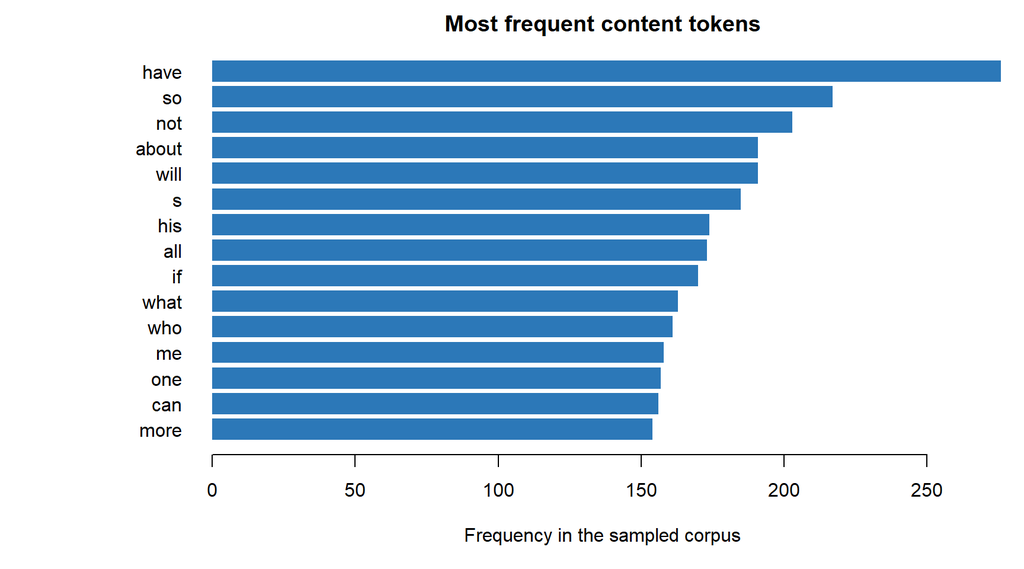

```r
old_par <- par(no.readonly = TRUE)
par(mar = c(5, 9, 2, 1), family = "sans")

barplot(
  rev(as.integer(top_tokens)),
  names.arg = rev(names(top_tokens)),
  horiz = TRUE,
  las = 1,
  col = "#2C78B8",
  border = NA,
  xlab = "Frequency in the sampled corpus",
  main = "Most frequent content tokens"
)
```

```r
par(old_par)
```

# Analytical choices and limitations

- **Chunked reading:** limits memory use and mirrors work with large production corpora.
- **Sampling:** speeds up initial exploration, but rare words and rare language patterns may be missed.
- **Token definition:** this first version retains alphabetic words and internal apostrophes. Emoji, numbers and punctuation are excluded and may need separate handling later.
- **Profanity filtering:** a short rule-based list is transparent but incomplete. Context-aware moderation and stakeholder review would improve it.
- **Model implications:** stopwords remain available for future n-gram modelling even though they are suppressed in the descriptive frequency chart.
- **Sensitivity:** results should later be compared across larger samples and alternative tokenization rules to test whether conclusions remain stable.

# Next step

The cleaned tokens can next be converted into unigram, bigram and trigram frequency tables. Those candidate models can be compared using held-out text, prediction coverage, accuracy and memory use before building the final Shiny application.